# Lab5

Whitney Willoz

11/10/2021

##Lab 5

Load in the data:

```r
library(tidyverse)
library(lubridate)
```

```r
library(maps)
acc <- read.csv("https://raw.githubusercontent.com/xdaiISU/ds202materials/master/hwlabs/fars2017/accident.csv", stringsAsFactors = FALSE)

person <- read.csv("https://raw.githubusercontent.com/xdaiISU/ds202materials/master/hwlabs/fars2017/person.csv", stringsAsFactors = FALSE)
```

1)Create a data frame containing the persons who are fatally hurt in the accidents (see FARS manual and look up variable INJ_SEV)

```r
fatalH <- person %>%
  filter(INJ_SEV == 4)
```

2)Create a data frame containing the most dangerous vehicle make in each state. The number of persons fatally hit in the vehicle make is used to assess the (non-)safety of a make. Make sure to handle the missing values appropriately. (look up variable MAKE)

```r
dangMakes <- fatalH %>%
  filter(!is.na(MAKE)) %>%
  group_by(MAKE, STATE) %>%
  summarise(FatalCount = n()) %>%
  arrange(-FatalCount) %>%
  group_by(STATE) %>%
  filter(FatalCount == max(FatalCount))
```

3)Create a map, and label each state with the most dangerous vehicle. Discuss the definition of the most dangerous vehicle, and what you find from the map. (Hint: Read the description for the STATE and COUNTY columns in the FARS manual. The state & county codes are Geographic Locator Codes (GLCs) from the General Services Administration’s (GSA) publication. Use readxl::read_xlsx to read in the GLCs.)

```r
states <- readxl::read_xlsx("FRPP_GLC_-_United_StatesNov42021.xlsx")
```

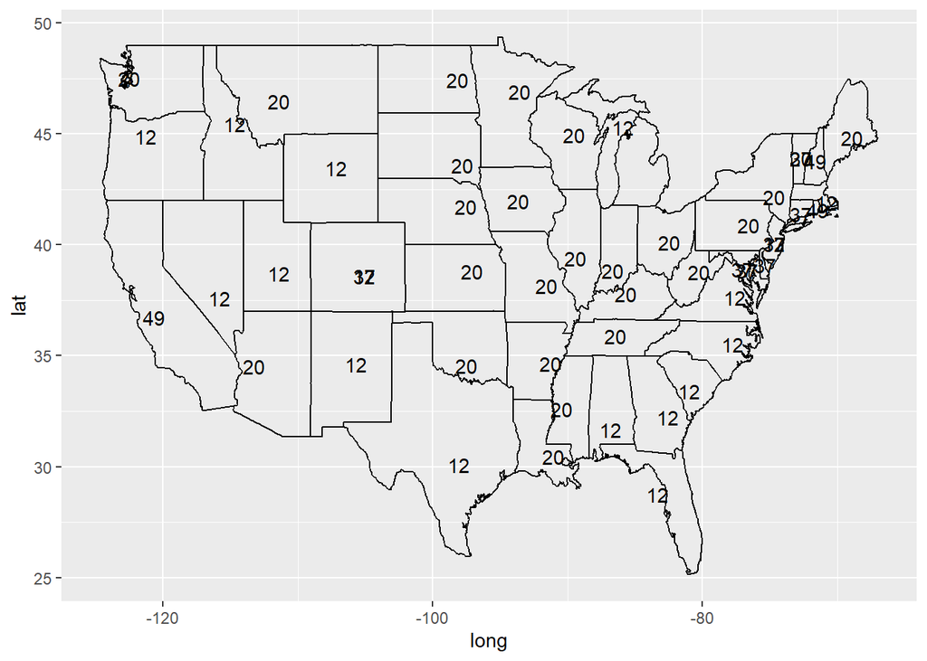

```r
statesmap <- map_data("state") %>%
  mutate(
    region = toupper(region)
  ) %>%
  left_join(states %>%
              mutate(
                `State Code` = as.integer(`State Code`)
              ) %>% select(`State Name`, `State Code`) %>% distinct, by = c(region = 'State Name')) %>%
  group_by(`State Code`) %>%
  summarize(
    long = mean(long),
    lat = mean(lat)
  ) %>%
  left_join(dangMakes, by = c('State Code' = 'STATE'))


map_data("state") %>%
  ggplot(aes(x = long, y = lat)) +
  geom_path(aes(group = group)) +
  geom_text(aes(label = MAKE), data = statesmap)
```

4)Join the accident and person table (work out which variable(s) to use)

```r
joinedData <- left_join(person, acc, by = "ST_CASE")
```

5)Tally the number of accidents by day of the week (DAY_WEEK), hour of the day (HOUR) and gender (SEX). Visualize the results and explain what you find.

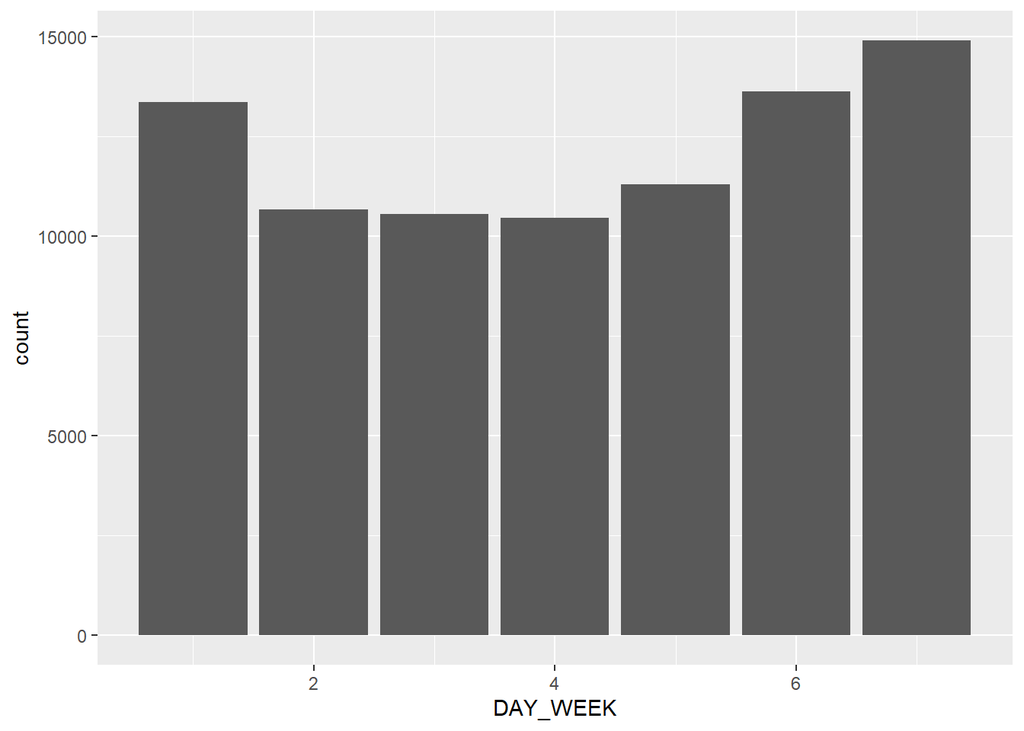

```r
#day_week
joinedData %>%
  group_by(DAY_WEEK) %>%
  summarize(totalAcc = n()) %>%
  ggplot(aes(x=DAY_WEEK, weight = totalAcc)) + geom_bar()
```

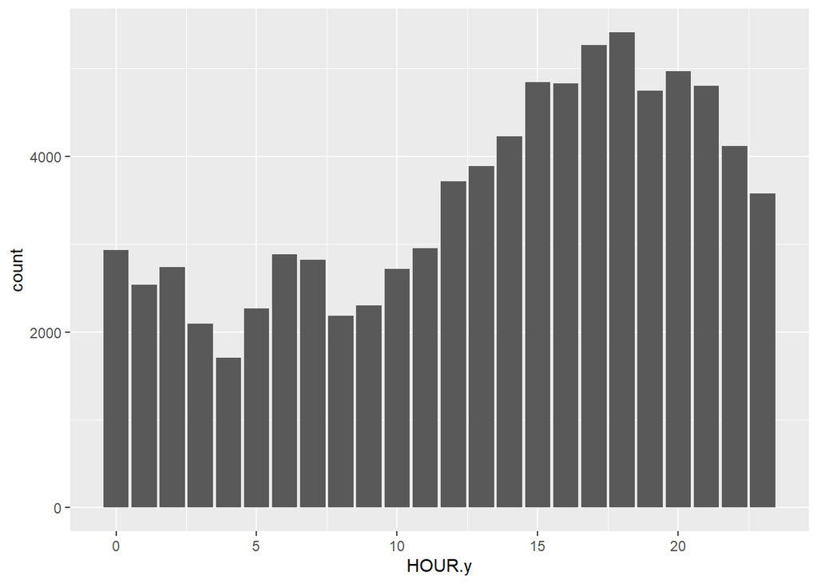

```r
#Hour
joinedData %>%
  group_by(HOUR.y) %>%
  summarize(totalAcc = n()) %>%
  filter(!HOUR.y == 99) %>%
  ggplot(aes(x=HOUR.y, weight = totalAcc)) + geom_bar()
```

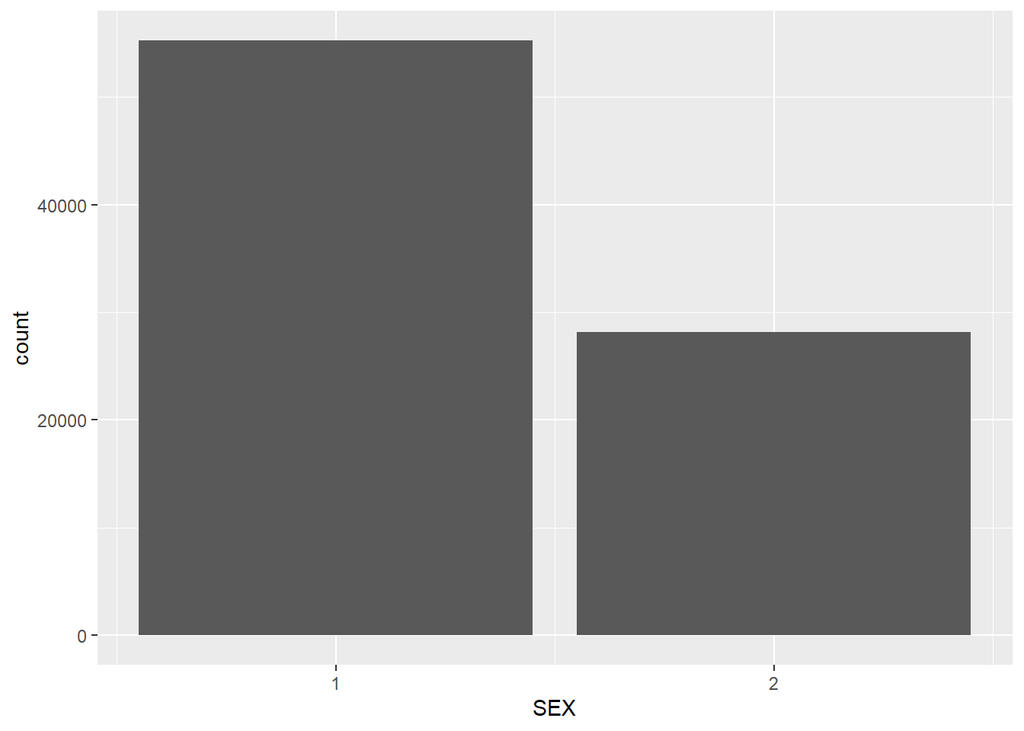

```r
#gender
joinedData %>%
  group_by(SEX) %>%
  summarize(totalAcc = n()) %>%
  filter(!SEX > 2) %>%
  ggplot(aes(x=SEX, weight = totalAcc)) + geom_bar() + scale_x_continuous(breaks = 1:2)
```

6)Now plot a choropleth map of the number of deaths on a county level. Also explain what you find.

Answer:Most automobile deaths happen in major cities like chicago,southern florida, and LA areas.

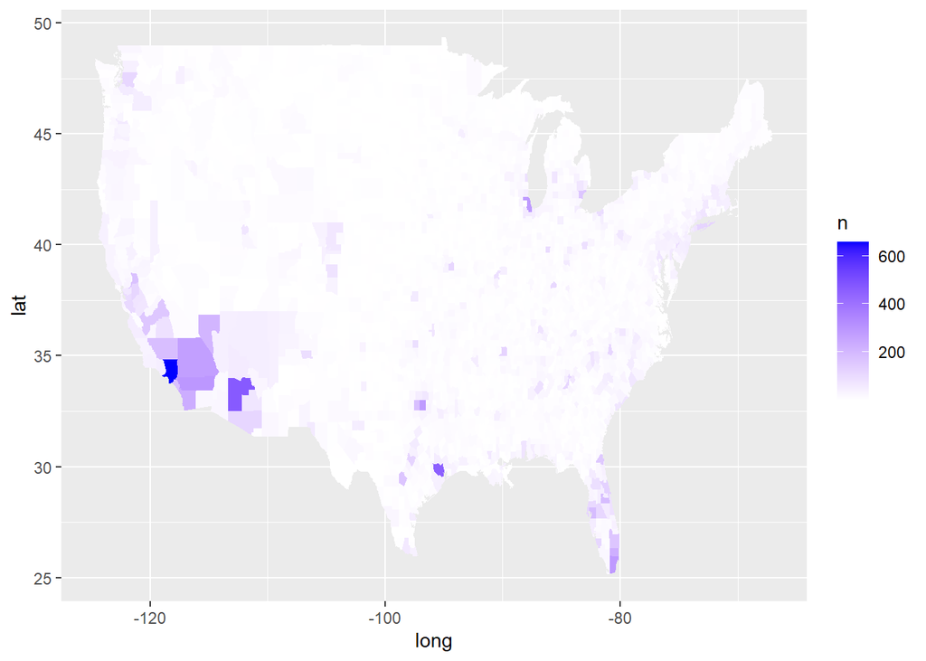

```r
dat1<-fatalH %>%
  group_by(STATE, COUNTY) %>%
  count

countymap <- map_data("county") %>%
  mutate(
    region = toupper(region),
    subregion = toupper(subregion)
  ) %>%
  left_join(states %>%
              mutate(
                `State Code` = as.integer(`State Code`), `County Code` = as.integer(`County Code`)
              ) %>% select(`State Name`, `State Code`, `County Name`, `County Code`) %>% distinct, by = c(region = 'State Name', subregion = 'County Name')) %>%
  left_join(dat1, by = c('State Code' = 'STATE', 'County Code' = 'COUNTY'))

countymap %>% ggplot(aes(long, lat)) + geom_polygon(aes(group = group, fill = n)) +
  scale_fill_gradient2(
    low = 'white',
    high = 'blue',
    na.value = 'white'
  )
```